# Sprawozdanie firmy Wombat Grylls za rok 2024

Grupa B

2025-01-20

# Wprowadzenie

Spółka Wombat Grylls zajmuje się organizowaniem wycieczek do różnych miejsc na terenie Polski. Wakacje stanowią ważny element życia każdego człowieka, są czasem odpoczynku, nagrodą za ciężką pracę oraz szansą na poznanie nowych kultur lub zwyczajów. Celem naszej firmy jest pośredniczenie w okresie przygotowawczym do wyjazdu i usprawnienie wszelkich formalności tak, aby klienci mogli skupić się na odpoczynku i wartościowym czasie z rodziną i przjaciółmi.

# Analiza danych

Po roku funkcjonowania naszej firmy Wombat Grylls sp. z o.o. przygotowany został ten raport w celu podsumowania wyników działania spółki, określenia słabych i mocnych stron oraz możliwych strategii rozwoju w kolejnych latach.

## Popularność wycieczek

Raport rozpoczynamy od analizy popularności oferowanych przez nas wycieczek. Pomoże nam to w zidentyfikowaniu słabych punktów w naszej ofercie oraz przybliży jasny plan poprawy naszych usług.

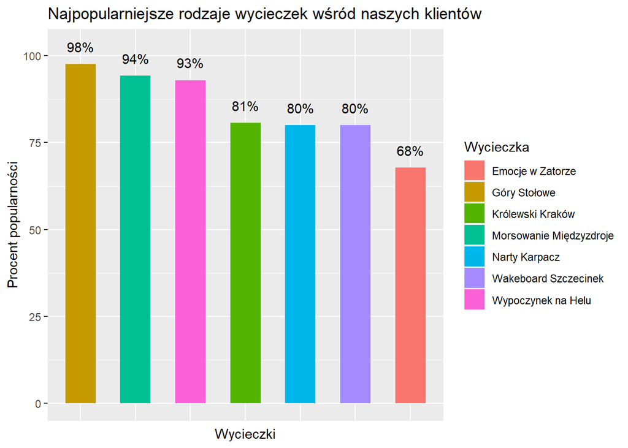

Wycieczki: Emocje w Zatorze nie cieszą się satysfakcjonującym poziomem popularności, po zakończeniu każdej wycieczki z tych kategorii, powiniśmy poprosić klientów o wyrażenie swoich opinii i dostować się do ich głosów.

## Analiza rentowności

Efektywne zarządzanie kosztami oraz maksymalizacja zysków to kluczowe elementy sukcesu każdej firmy w branży turystycznej. Analiza kosztów i zysków poszczególnych wycieczek pozwala zidentyfikować:

- Wycieczki, które przynoszą największy zysk, co może wskazywać na ich wysoką atrakcyjność dla klientów.
- Wycieczki generujące wysokie koszty, które mogą wymagać optymalizacji lub zmiany oferty.
- Ogólną strukturę przychodów i kosztów, co umożliwia określenie, które aspekty działalności wymagają szczególnej uwagi.

Celem tej analizy jest dostarczenie klarownego obrazu rentowności organizowanych wycieczek, co umożliwi podejmowanie świadomych decyzji dotyczących rozwoju oferty, optymalizacji kosztów oraz zwiększenia zyskowności firmy.

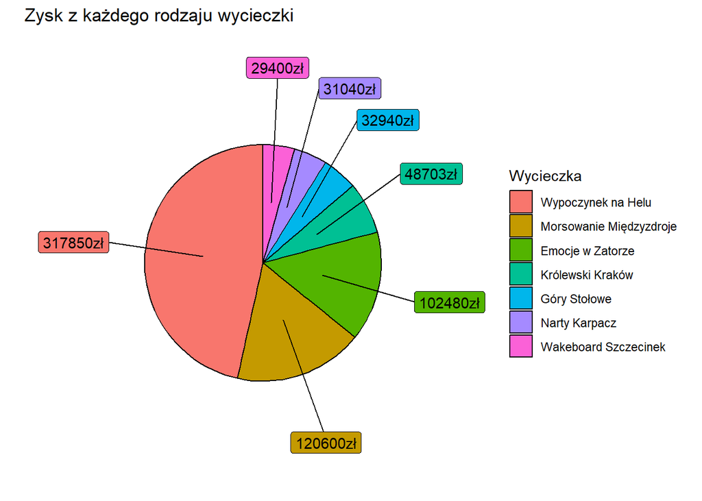

Trzy najbardziej dochodowe wycieczki to Wypoczynek na Helu, Morsowanie Międzyzdroje, Emocje w Zatorze. W następnym roku naszej działalności powiniśmy zainwestować w infrastrukturę umożliwiającą zwiększenie liczby tych wycieczek, aby zmaksymalizować nasz zysk.

## Udział usług dodatkowych w zyskach

Wykres przedstawia analizę zysków wygenerowanych przez różne rodzaje usług dodatkowych. Usługi dodatkowe stanowią istotny element oferty, który nie tylko zwiększa atrakcyjność wycieczek, ale również przyczynia się do wzrostu dochodów. Dzięki szczegółowemu zestawieniu można zidentyfikować najbardziej dochodowe usługi, a także te, które wymagają optymalizacji lub większej promocji.

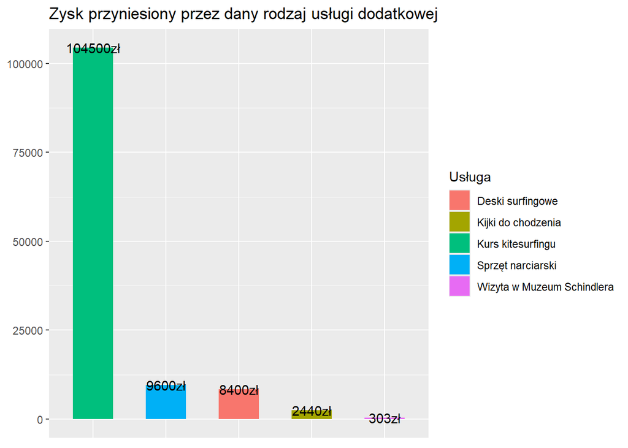

## Analiza kosztów u kontrahentów

Poniższy wykres kołowy przedstawia rozkład kosztów poniesionych na rzecz poszczególnych kontrahentów. Każdy sektor reprezentuje kwotę wydaną na współpracę z danym podmiotem, co pozwala zidentyfikować najważniejszych partnerów pod względem finansowym. Największe nakłady zostały poniesione na rzecz sieci hoteli Gromada oraz szkoły kitesurfingu ProKajciarz, co wskazuje na ich istotne znaczenie w realizacji oferty. Analiza ta umożliwia ocenę struktury wydatków i może stanowić podstawę do negocjacji oraz optymalizacji kosztów współpracy z poszczególnymi partnerami.

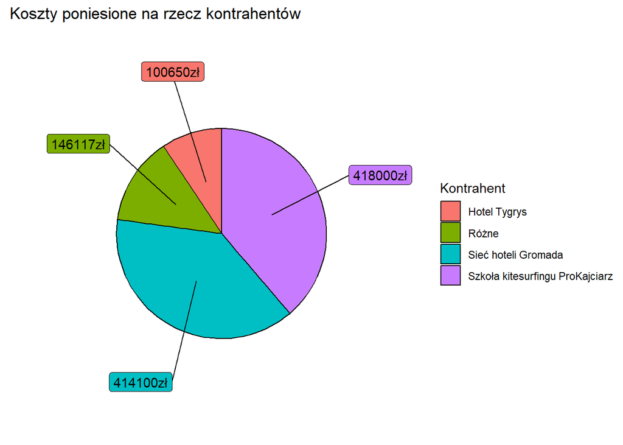

## Analiza zysków i strat na miesięcznej podstawie

Analiza zysków w poszczególnych miesiącach ma na celu ocenę wyników finansowych w rozbiciu na okresy miesięczne, co pozwala na dokładniejsze zrozumienie dynamiki przychodów oraz kosztów. Analiza uwzględnia dane finansowe za ostatnie 12 miesięcy, przy czym każdy miesiąc został dokładnie zbadany pod kątem przychodów oraz kosztów. Celem jest zidentyfikowanie kluczowych trendów i wzorców, które mogą pomóc w lepszym planowaniu przyszłych działań biznesowych.

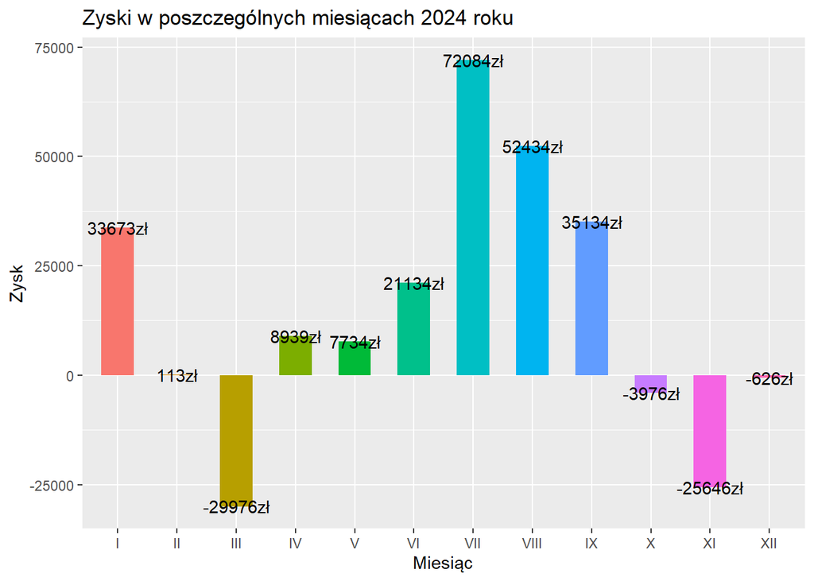

Aby utrzymać i zwiększyć zyski, rekomendujemy rozszerzenie oferty wycieczek latem oraz w styczniu, co odpowiada na wzrost popytu w tych okresach. Można rozważyć wprowadzenie nowych atrakcji lub promocji skierowanych do różnych grup docelowych, co zwiększy naszą konkurencyjność na rynku. Dodatkowo, warto zainwestować w marketing, który wzmocni naszą obecność w tych miesiącach.

W przypadku miesięcy, w których notujemy straty, takich jak marzec i listopad, warto przeanalizować, czy istnieją czynniki zewnętrzne, które mogłyby wpłynąć na wyniki, takie jak warunki pogodowe, zmiany w preferencjach turystów czy globalne kryzysy. Można także spróbować dostosować ofertę do oczekiwań klientów w tych okresach – na przykład poprzez oferowanie tańszych, krótkoterminowych wycieczek, które będą atrakcyjniejsze w mniej popularnych miesiącach. Ostatecznie, balansowanie oferty i dostosowywanie jej do sezonowych zmienności pozwoli nam zoptymalizować wyniki finansowe przez cały rok.

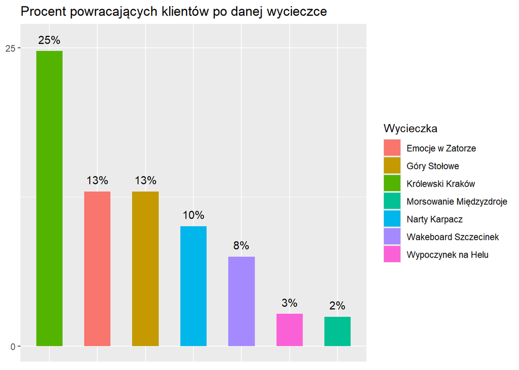

Zoptymalizowanie tych dwóch aspektów — lojalności klientów oraz jakości obsługi — pomoże nie tylko zwiększyć liczbę powracających uczestników kursów, ale także wpłynie pozytywnie na reputację firmy i długoterminowy wzrost zysków.

## Trendy demograficzne

Analiza popularności wycieczek pomiędzy oboma płciami umożliwi nam lepsze dostosowanie oferty do wymagań danej grupy oraz identyfikację ewentualnych różnic w preferencjach, które mogą wpłynąć na kierunki podróży, rodzaje aktywności czy preferencje dotyczące standardu zakwaterowania. Analiza tych trendów pozwoli również na opracowanie bardziej spersonalizowanych ofert, które przyciągną większą liczbę klientów z obu płci, zwiększając tym samym efektywność działań marketingowych oraz poprawiając wyniki sprzedaży.

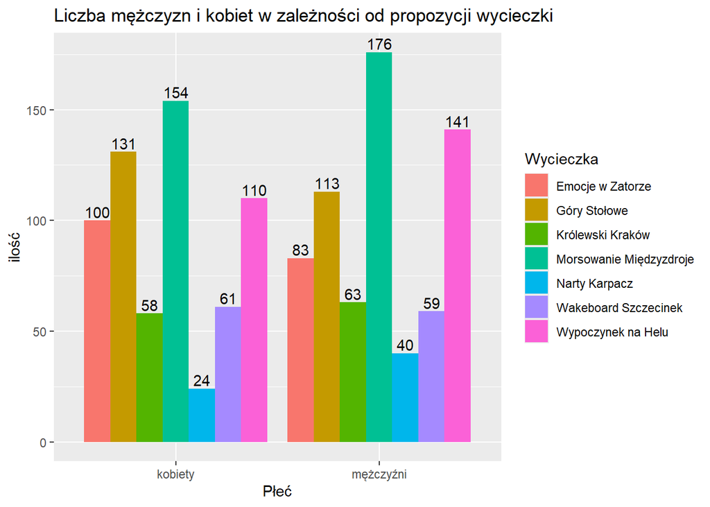

Wycieczki Emocje w Zatorze, Góry Stołowe cieszą się większą popularnością wśród kobiet. Aby jeszcze bardziej zwiększyć ich atrakcyjność, warto rozważyć przeprowadzenie kampanii marketingowej skierowanej specjalnie do tej grupy docelowej, co może przyczynić się do dalszego wzrostu popularności wśród kobiet. Wycieczki Morsowanie Międzyzdroje, Narty Karpacz, Wypoczynek na Helu są bardziej popularne wśród mężczyzn. W związku z tym, aby jeszcze skuteczniej przyciągnąć tę grupę, powinniśmy zwiększyć liczbę reklam skierowanych bezpośrednio do mężczyzn, co może przyczynić się do dalszego wzrostu liczby uczestników męskiej części tych wycieczek.

## Dynamika liczby klientów miesięcznie

Wykres przedstawia liczbę klientów odwiedzających naszą firmę w poszczególnych miesiącach. Analiza ta pozwala na ocenę dynamiki ruchu klientów w ciągu roku, uwzględniając zmiany sezonowe oraz potencjalne czynniki wpływające na frekwencję, takie jak promocje, wydarzenia specjalne czy zmiany rynkowe. Dzięki temu wykresowi możemy zidentyfikować miesiące o najwyższym oraz najniższym natężeniu klientów, co umożliwia optymalizację działań marketingowych, dostosowanie oferty i lepsze planowanie zasobów w okresach o zmiennej liczbie odwiedzających.

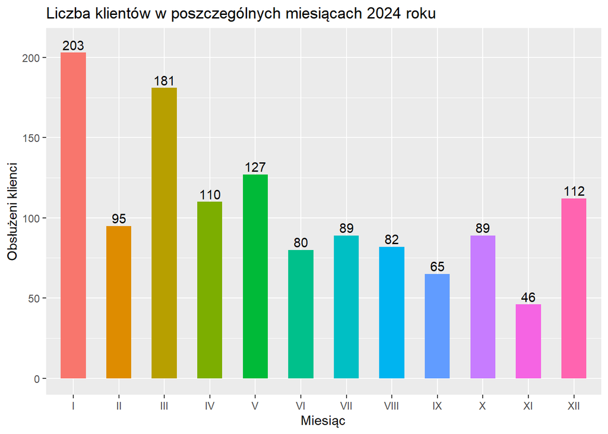

Pomimo, że w marcu udzieliliśmy naszych usług drugiej największej liczbie osób to ponieśliśmy największe straty na przestrzeni roku. W związku z tym powiniśmy przenegocjować nasze umowy z kontrahentami wycieczek, które odbyły się w tym miesiącu oraz nałożyć większą marżę na nasze usługi.

# Podsumowanie

Po pierwszym roku działalności osiągnęliśmy zysk, co stanowi solidną podstawę do dalszego rozwoju. W związku z tym warto rozważyć rozszerzenie naszej kadry, poszerzenie oferty wycieczek oraz zakup nowych autokarów. Ponadto, zaleca się nawiązanie współpracy z liniami lotniczymi, aby umożliwić wprowadzenie wycieczek międzynarodowych do naszej oferty. Kolejnym celem na przyszłość jest zwiększenie zysków w miesiącach zimowych i wiosennych. Aby to osiągnąć, warto przeanalizować możliwości renegocjacji istniejących umów oraz zawarcie nowych kontraktów z dotychczasowymi i potencjalnymi kontrahentami.